# Spatial Upscaling

Applied Geodata Science II, fall semester 2023

Noémie Wellinger

2024-01-09

# 1. Background

## 1.1. Literature discussion: Ludwig et al. (2023)

*Explain the difference between a random cross-validation and a spatial cross-validation.*

Random and spatial cross-validation use different partitioning methods for the folds. For random cross-validation, the n folds are chosen randomly among the whole dataset. Spatial in the context of this paper means geographical space (longitude and latitude). For spatial cross-validation, the data is partitioned according to the “Euclidean geographic distance distribution between training data and all prediction locations” (Ludwig et al., 2023). In the approach they follow, each fold should consist of similar distances to the remaining reference data.

*In spatial upscaling, we model the target based on environmental covariates. This implies that we assume the training data to sufficiently represent the conditions on which the model will be applied for generating predictions. Prediction errors may increase with an increasing distance of the prediction location from the training locations. The paper by Ludwig et al. (2023) considers this “distance” as a geographical distance in Euclidian space. Do you see an alternative to measuring a distance that considers the task of spatial upscaling based on environmental covariates more directly?*

Rather than considering geographical space, use the feature space of the environmental covariates. In this case, Euclidian distance (or better, Normalized Euclidian distance, since the environmental covariates likely have different unit measures) would measure the similarity of the environment of the training locations. The folds would then contain data that is similar, making the folds dissimilar to each other. This is also done by Ludwig et al. (2023) using k-means clustering. However, they point out that this method of cross-validation is not suitable to estimate overall map accuracy.

## 1.2 Data

Observational leaf nitrogen (N) content. Environmental covariates with global coverage (limited subset):

- leafN: leaf nitrogen content, in mass-based concentration units (gN gDM)
- lon: longitude in decimal degrees east
- lat: latitude in decimal degrees north
- elv: Elevation above sea level (m)
- mat: mean annual temperature (degrees Celsius)
- map: mean annual precipitation (mm yr)
- ndep: atmospheric nitrogen deposition g m
- yrmai: mean annual daily irradiance µmol m
- sSpecies: species name of the plant on which leaf N was measured

# 2. Analysis

## 2.1 Random cross-validation

The aim is to use Random Forest to perform a 5-fold cross-validation with the leaf N data (leafN) and the following predictors:

- elv: Elevation above sea level (m)
- mat: mean annual temperature (degrees Celsius)
- map: mean annual precipitation (mm yr)
- ndep: atmospheric nitrogen deposition g m
- mai: mean annual daily irradiance µmol m
- Species: species name of the plant on which leaf N was measured

Training and testing data are split in a 75%/25% proportion, with `leafN` as the stratification variable. This ensures that the distribution of the target variable (`leafN`) is similar in both the training and testing sets.

Using the `ranger` package, a Random Forest model was fitted with random 5-fold cross-validation.

```r
# The same model formulation is in the previous chapter
pp <- recipes::recipe(leafN ~ elv + mat + map + ndep + mai + Species,
                      data = dfs) |>
  recipes::step_center(recipes::all_numeric(), -recipes::all_outcomes()) |>
  recipes::step_scale(recipes::all_numeric(), -recipes::all_outcomes())

mod_rn_cv <- caret::train(
  pp,
  data = dfs |> drop_na(),
  method = "ranger",
  trControl = trainControl(method = "cv", number = 5, savePredictions = "final"),
  # Set hyperparameters to other than default:
    tuneGrid = expand.grid( .mtry = 3,
                          .min.node.size = 12,
                          .splitrule = "variance"),
  metric = "RMSE",
  replace = FALSE,
  sample.fraction = 0.5,
  num.trees = 500,    # high number ok since no hyperparam tuning
  seed = 32 # for reproducibility
)
```

## 2.2 Spatial cross-validation

View the distribution of data across the globe:

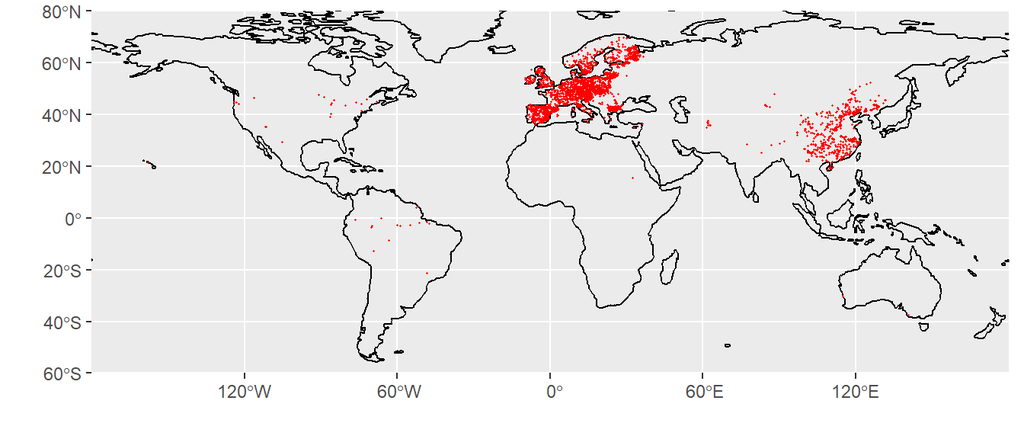

Figure 1: Global distribution of observational data.

The data appears to be spatially biased, with a vast majority of data points in Europe, some in Eastern Asia, and little to none in the rest of the world. The accuracy of a model trained on this data and upscaled to the whole globe will vary over geographical space. Models perform better for data that is similar to the training data. We can assume that geographical distance to observational data points in this case, is a pretty good metric for similar leaf N content. Therefore, the upscaling should work best, where there is a lot of observational data. There might also be geographically distant areas that show similar leaf N and covariates to the observation. There, we should also see a better model performance.

### 2.2.1 K-means clustering

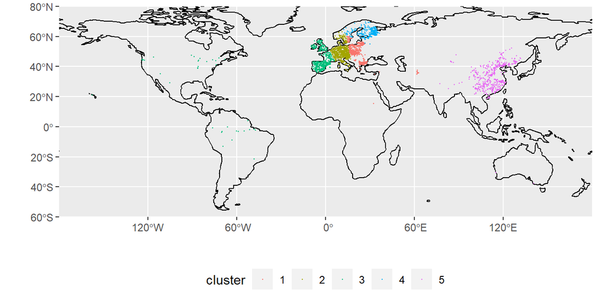

Figure 2: Map of geographical spatial clusters of for 5-fold cross validation.

```r
# cluster the data
clusters <- kmeans(
  dfs |> dplyr::select(lon, lat),
  centers = 5
)

dfs_cluster <- dfs |>
  mutate(cluster = as.factor(clusters$cluster))

ggplot() +
  geom_sf(data = coast,
          colour = 'black',
          size = 0.2) +
  coord_sf(
    ylim = c(-60, 80),
    expand = FALSE) +
  # plot points on map
  geom_point(data = dfs_cluster, aes(x = lon, y = lat, color = cluster),  size = 0.2) +
  labs(x = "", y = "") +
  theme(legend.position = "bottom")
```

The distribution of leaf N by cluster looks like this:

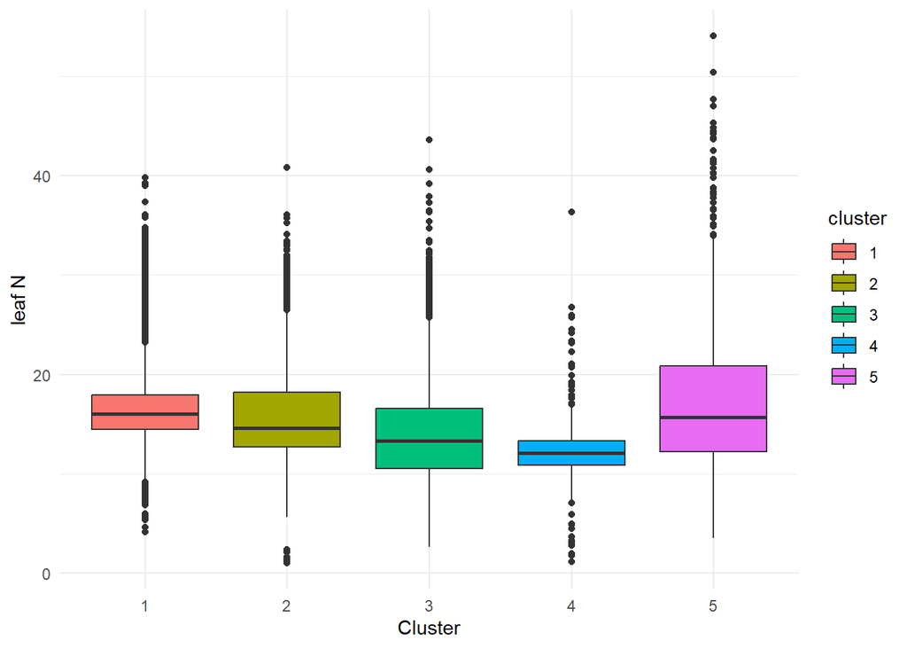

Figure 3: Boxplot showing the distribution of leaf nitrogen content by spatial cluster.

The clusters do not all look markedly different. Western Europe/Americas and Central Europe look very similar. Eastern Europe and Scandinavia have lower variance. Eastern Asia has the highest variance.

### 2.2.2. Data splitting and model training

The clusters serve as pre-defined groups for the k-fold-cross-validation.

```r
# create folds based on clusters
# assuming 'df' contains the data and a column called 'cluster' containing the
# result of the k-means clustering
group_folds_train <- purrr::map(
  seq(length(unique(dfs_cluster$cluster))),
  ~ {
    dfs_cluster |>
      select(cluster) |>
      mutate(idx = 1:n()) |>
      filter(cluster != .) |>
      pull(idx)
  }
)

group_folds_test <- purrr::map(
  seq(length(unique(dfs_cluster$cluster))),
  ~ {
    dfs_cluster |>
      select(cluster) |>
      mutate(idx = 1:n()) |>
      filter(cluster == .) |>
      pull(idx)
  }
)
```

A function is created, that trains a random forest model on a given set of rows and predicts on a disjunct set of rows. Then, the function is applied to each custom fold.

```r
# create a function that trains a random forest model on a given set of rows and
# predicts on a disjunct set of rows
train_test_by_fold <- function(df, idx_train, idx_test, target, predictors){
  mod <- ranger::ranger(
    x =  as.data.frame(df[idx_train, predictors]),  # data frame with columns corresponding to predictors
    y =  as.vector(df[idx_train, target])[[1]],   # a vector of the target values (not a data frame!)
    # use as.vector() because otherwise it's a dataframe, but.. as.vector() produces a list
    # therefore use [[1]] at the end to extract the first vector out of the list
    mtry = 3,
    min.node.size = 12,
    #splitrule = "variance",
    replace = FALSE,
    sample.fraction = 0.5,
    num.trees = 500,    # high number ok since no hyperparam tuning
    seed = 32 # for reproducibility
  )
  pred <- predict(mod,       # the fitted model object
                  data = df[idx_test, predictors] # a data frame with columns corresponding to predictors
                  )

  compare <- data.frame(df[idx_test, target], pred$predictions)
  names(compare) <- c("obs", "pred")
  rsq <- yardstick::rsq(data = compare, estimate = pred, truth = obs)$.estimate # the R-squared determined on the validation set
  rmse <- yardstick::rmse(data = compare, estimate = pred, truth = obs)$.estimate # the root mean square error on the validation set

  return(data.frame(rsq = rsq, rmse = rmse))
}

# apply function on each custom fold and collect validation results in a nice
# data frame
mod_spat_cv_stat <- purrr::map2_dfr(
  group_folds_train,
  group_folds_test,
  ~train_test_by_fold(dfs, .x, .y, target, predictors_all)
) |>
  dplyr::mutate(test_fold = 1:5)
```

## 2.3 Environmental cross-validation

For the third cross-validation, we consider five clusters of points in environmental space (or feature space) - spanned by the mean annual precipitation and the mean annual temperature.

### 2.3.1 K-means clustering

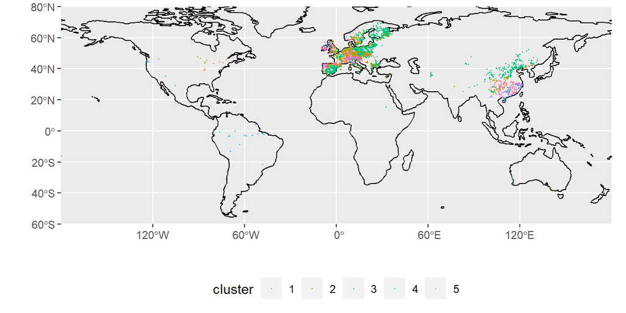

Figure 4: Map of environmental / feature space clusters for 5-fold cross validation.

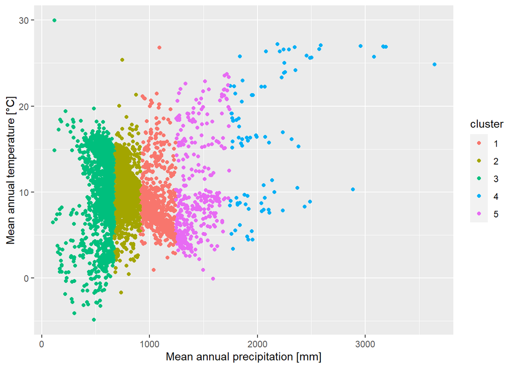

Figure 5: Plot of environmental clusters spanned between mean annual temperature [°C] and mean annual precipitation [mm].

```r
# cluster the data
clusters <- kmeans(
  dfs |> dplyr::select(mat, map),
  centers = 5
)
```

It seems that the clusters are created only according to precipitation, although temperature is given as an argument in the formula too. This happens, because the data is not normalized and the precipitation has a much larger value range than the temperature.

### 2.3.2. Data splitting and model training

```r
# create folds based on clusters
# assuming 'df' contains the data and a column called 'cluster' containing the
# result of the k-means clustering
group_folds_train <- purrr::map(
  seq(length(unique(dfs_env$cluster))),
  ~ {
    dfs_env |>
      select(cluster) |>
      mutate(idx = 1:n()) |>
      filter(cluster != .) |>
      pull(idx)
  }
)

group_folds_test <- purrr::map(
  seq(length(unique(dfs_env$cluster))),
  ~ {
    dfs_env |>
      select(cluster) |>
      mutate(idx = 1:n()) |>
      filter(cluster == .) |>
      pull(idx)
  }
)
# apply function on each custom fold and collect validation results in a nice data frame
mod_env_cv_stat <- purrr::map2_dfr(
  group_folds_train,
  group_folds_test,
  ~train_test_by_fold(dfs_env, .x, .y, target, predictors_all)
) |>
  dplyr::mutate(test_fold = 1:5)
```

# 3. Results and Discussion

Table 1: Error metrics of random 5-fold cross-validation

| Fold | RMSE | Rsquared |
| --- | --- | --- |
| 1 | 2.341 | 0.792 |
| 2 | 2.445 | 0.768 |
| 3 | 2.359 | 0.793 |
| 4 | 2.315 | 0.794 |
| 5 | 2.338 | 0.786 |
| mean | 2.360 | 0.787 |

```
##   Fold   RMSE Rsquared
## 1    1 3.0520   0.5160
## 2    2 3.2650   0.6210
## 3    3 3.7650   0.5330
## 4    4 2.2660   0.1740
## 5    5 6.9930   0.0720
## 6 mean 3.8682   0.3832
```

Table 2: Error metrics of spatial 5-fold cross-validation

| Fold | RMSE | Rsquared |
| --- | --- | --- |
| 1 | 3.0520 | 0.5160 |
| 2 | 3.2650 | 0.6210 |
| 3 | 3.7650 | 0.5330 |
| 4 | 2.2660 | 0.1740 |
| 5 | 6.9930 | 0.0720 |
| mean | 3.8682 | 0.3832 |

```
##   Fold   RMSE Rsquared
## 1    1 2.9030    0.663
## 2    2 3.1440    0.671
## 3    3 3.3860    0.522
## 4    4 4.6970    0.169
## 5    5 3.1570    0.610
## 6 mean 3.4574    0.527
```

Table 3: Error metrics of environmental 5-fold cross-validation

| Fold | RMSE | Rsquared |
| --- | --- | --- |
| 1 | 2.9030 | 0.663 |
| 2 | 3.1440 | 0.671 |
| 3 | 3.3860 | 0.522 |
| 4 | 4.6970 | 0.169 |
| 5 | 3.1570 | 0.610 |
| mean | 3.4574 | 0.527 |

The error metrics of the three models trained on different cross-validation methods, are summarized in Table 1 (random CV), Table 2 (spatial CV), and Table 3 (environmental CV).

This shows the importance of defining an area of applicability, like Ludwig et al. (2023) propose, to avoid making predictions in an area that doesn’t have similar enough reference data.

It seems a bit counter-intuitive to me, that the environmental CV performs better and is thus less prone to spatial overfitting than the spatial CV. I would have expected that geographical closeness is not necessarily a better clustering basis than environmental similarity. But perhaps this can be attributed to the choice of environmental covariates (mean annual temperature and precipitation). Firstly, the variables were not normalized, causing the clustering to be much more dependent on precipitation than temperature. And secondly, these may not be the most distinctive variables to describe a local environment. A comparison with other covariate tuples, or with more than two covariates for clustering could be interesting.

# References

Ludwig, M., Moreno-Martinez, A., Hölzel, N., Pebesma, E., & Meyer, H. (2023). Assessing and improving the transferability of current global spatial prediction models. Global Ecology and Biogeography, 32, 356–368. https://doi.org/10.1111/geb.13635